Degree and satisfaction with financial situation Introduction: Is there relationship between the highest level of education of a person and personâs satisfactionwith self financial situation? I want to know how education affects the humanâs life and his #calmnessI think it is interesting question not only for me. Data: The original data is from the General Social Surveys from 1972 to 2012. The data was collected by asking surveyâs question to English/Spanish speaking persons 18 years of age or older, living in the United States. The data was merged into one cumulative file provided by ICPSR (1). The data used for this study is an modified extract by Coursera from that file, all missing value replaced by âNAâ.

The cases are the answers by one respondent to General Social Surveyâs questions, and Case Identification and Year of survey.

Because of surveys this is an observational study.

I will use two categorical variables - degree and satfin. DEGREE is a highest degree of respondents. The question is âIf finished 9th-12th grade: Did you ever get a high school diploma or a GED certificate?â SATFIN is a respondentâs SATISFACTION WITH his FINANCIAL SITUATION. The question is âWe are interested in how people are getting along financially these days. So far as you and your family are concerned, would you say that you are pretty well satisfied with your present financial situation, more or less satisfied, or not satisfied at all?â

The population of interest is the US population. The data contains the answers from English/Spanish speaking persons thus the findings from this analysis can not be generalized to that population but can be generalized to English/Spanish speaking adult population of the US. Potential sources of bias are Convenience sample (it can be difficult to survey some person) and Non-response (some persons donât response on some question).

The data can not be used to establish causal links between the variables of interest because of bias discussed above.

Exploratory data analysis: The used variables can contain some empty value coded as NA. I decide cutoff those observation units The new dataset has 51498 observations of 3 variables. degree can contain 5 levels: âLt High Schoolâ,âHigh Schoolâ,âJunior Collegeâ, âBachelorâ,âGraduateâ.satfin can contain 3 levels: âSatisfiedâ, âMore Or Lessâ, âNot At All Satâ.

```r
load(url("http://bit.ly/dasi_gss_data"))
```

Cutoff all NAâs, the new dataset gss does not contain NA

```r
gss<- subset(gss, degree != 'NA' & satfin != 'NA', select = c(caseid, degree, satfin))
```

New dataset gss contains three variables with no NAâs as values

```r
str(gss)
```

```
## 'data.frame':    51498 obs. of  3 variables:
##  $ caseid: int  1 2 3 4 5 6 7 8 9 10 ...
##  $ degree: Factor w/ 5 levels "Lt High School",..: 4 1 2 4 2 2 2 4 2 2 ...
##  $ satfin: Factor w/ 3 levels "Satisfied","More Or Less",..: 3 2 1 3 1 2 2 3 2 3 ...
```

```r
nrow(gss)
```

```
## [1] 51498
```

```r
ncol(gss)
```

```
## [1] 3
```

```r
summary(gss$degree)
```

```
## Lt High School    High School Junior College       Bachelor       Graduate
##          11163          26900           2728           7233           3474
```

```r
summary(gss$satfin)
```

```
##      Satisfied   More Or Less Not At All Sat
##          15069          22754          13675
```

```
H0 (nothing going on): Satisfaction with financial situation and degree are independent.
The exploratory data analysis suggests that satisfaction with self financial situation
depends on degree of person.
```

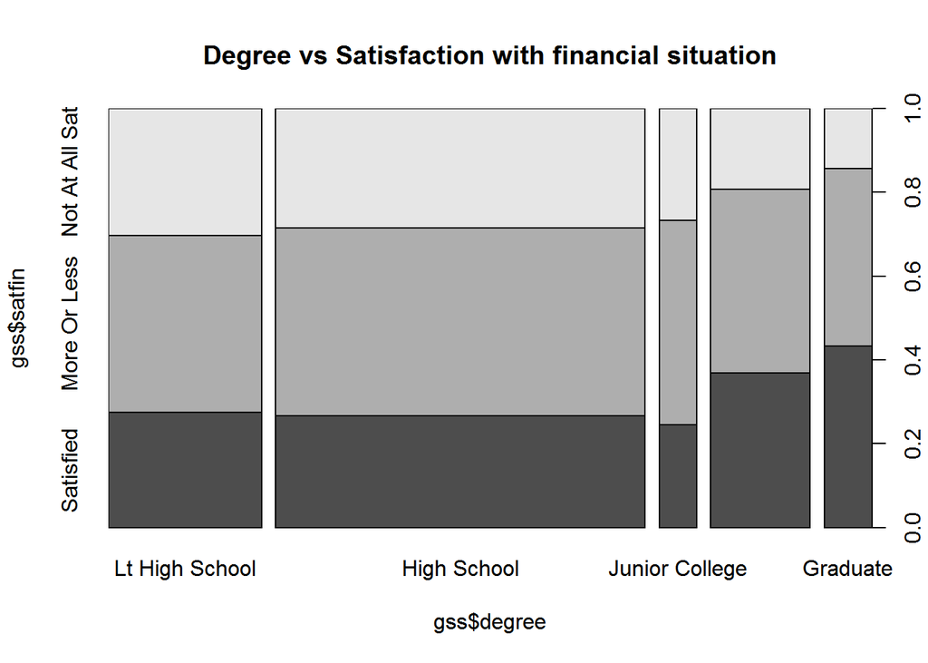

```r
plot(gss$satfin ~ gss$degree, main="Degree vs Satisfaction with financial situation")
```

```r
x <- by(gss$satfin,gss$degree,summary)
y <- sapply(1:nrow(x),function(i) rbind(x[[i]]))
dimnames(y) = list("Satisfaction" = names(x[[1]]),"Degree" = names(x))
```

```r
addmargins(y)
```

```
##                 Degree
## Satisfaction     Lt High School High School Junior College Bachelor
##   Satisfied                3065        7162            669     2669
##   More Or Less             4710       12068           1332     3171
##   Not At All Sat           3388        7670            727     1393
##   Sum                     11163       26900           2728     7233
##                 Degree
## Satisfaction     Graduate   Sum
##   Satisfied          1504 15069
##   More Or Less       1473 22754
##   Not At All Sat      497 13675
##   Sum                3474 51498
```

```r
chisq.test(y)$expected
```

```
##                 Degree
## Satisfaction     Lt High School High School Junior College Bachelor
##   Satisfied                3266        7871          798.2     2116
##   More Or Less             4932       11886         1205.3     3196
##   Not At All Sat           2964        7143          724.4     1921
##                 Degree
## Satisfaction     Graduate
##   Satisfied        1016.5
##   More Or Less     1535.0
##   Not At All Sat    922.5
```

```r
chisq.test(y)
```

```
##
##  Pearson's Chi-squared test
##
## data:  y
## X-squared = 944.8, df = 8, p-value < 2.2e-16
```

Exact p-value = 1.2474 Ã 10-198 The p-value is so tiny that we reject the null hypothesis.

Conclusion: These data provide convincing evidence that degree of person and his satisfaction of his financial situation are associated. But that is observational study so we can not conclude that gaining higher degree is making people more satisfied. Also there is possibility of existence of some confounders like life factors, e.g.Â age etc, that we donât studied here. References: General Social Survey Cumulative File, 1972-2012 Coursera Extract, modified for Data Analysis and Statistical Inference course (Duke University), all missing values have been recoded to missing (NA), link to dataset - http://bit.ly/dasi_gss_data Original Cumulative File: Smith, Tom W., Michael Hout, and Peter V. Marsden. General Social Survey, 1972-2012 [Cumulative File]. ICPSR34802-v1. Storrs, CT: Roper Center for Public Opinion Research, University of Connecticut /Ann Arbor, MI: Inter-university Consortium for Political and Social Research [distributors], 2013-09-11. doi:10.3886/ICPSR34802.v1 Persistent URL: http://doi.org/10.3886/ICPSR34802.v1

Appendix: Below the data used for chi-squared independence test with totals:

```r
addmargins(y)
```

```
##                 Degree
## Satisfaction     Lt High School High School Junior College Bachelor
##   Satisfied                3065        7162            669     2669
##   More Or Less             4710       12068           1332     3171
##   Not At All Sat           3388        7670            727     1393
##   Sum                     11163       26900           2728     7233
##                 Degree
## Satisfaction     Graduate   Sum
##   Satisfied          1504 15069
##   More Or Less       1473 22754
##   Not At All Sat      497 13675
##   Sum                3474 51498
```

And chunk of original data (two variables):

```
gss[1:50,c(1,12,72)]
```

[output not shown]

[output cut: 36 more lines]